# h-2.2

Andrew Church HW2.2

```python
import pandas as pd

# load sample csv
df_gss_sample = pd.read_csv('gss_sample.csv', index_col=0, low_memory=False, encoding='utf8')

# load rows counts of full data
gss_full_row_counts = pd.read_csv('gss_full_row_counts.csv', index_col=0, low_memory=False, encoding='utf8')

# load years per variable data
gss_years_per_var = pd.read_csv('gss_data_years_per_var.csv', index_col=0, low_memory=False, encoding='utf8')

# load data dictionary
gss_data_dictionary =  pd.read_csv('gss_data_dictionary.csv', index_col=0, low_memory=False, encoding='latin1')
```

Question 1

Working with df_gss_sample, create a variable called mycols that is a list of ten (10) column names that are related to one another in some way. Create a new variable called df_gss_sample_ten_cols that contains only the ten (10) columns in mycols. In a markdown cell below this question, explain how your variables are related to one another.

```python
mycols = ['gunlaw', 'owngun', 'pistol', 'shotgun', 'rifle', 'gunsdrug', 'guns911', 'gunfirm', 'guninfo', 'semiguns']
df_gss_sample_ten_cols = df_gss_sample[mycols]
```

all variable names were taken from the GSS data search under the filter "guns". mycols is a specific subset of the columns in the df_gss_sample dataset, while df_gss_sample_ten_cols is a general subset that specifically contains the columns listed in the variable mycols.

Question 2

In a markdown cell below this question, address the following:

How does gss_sample relate to gss_full_row_counts? If we assume gss_sample is a sample of a larger dataset of GSS data, why would we want some information about the full rows counts from the dataset? Generally speaking, what information is contained in the gss_years_per_var and gss_data_dictionary DataFrames? How can we use these sources to better understand our sample?

gss_sample is what it sounds like, a smaller subset of GSS with less columns and observations, whereas gss_full_row_counts contains all observations for the same number of columns as gss_sample. the use of gss_full_row_counts is likely to check if gss_sample is accurate in its observations. the info in gss_years_per_var is likely centered around each observation within the main GSS dataset and how many years it is being recorded and which years, while the gss_data_dicitionary is likely a big dataset full of all metadata for GSS. These are particularly helpful for tracing back observations and variables to their years and comparing based on time and even location (which I assume is in the data dictionary).

Question 3

In a code cell below this question, use the value_counts method to display a count for each unique value found in the zodiac column of df_gss_sample. Display the result as a DataFrame.

```python
df_gss_sample['zodiac'].value_counts()
```

```
zodiac
6.0     297
5.0     288
12.0    285
2.0     281
11.0    273
7.0     266
4.0     261
10.0    256
8.0     248
1.0     238
9.0     237
3.0     236
Name: count, dtype: int64
```

Question 4

In a code cell below this question, display a scatter plot depicting the realinc variable on one axis and the respondents occupational prestige score based on the 2010 Census occupation classification.

```python
import seaborn as sns
import matplotlib.pyplot as plt
```

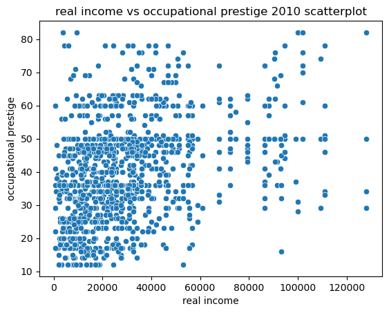

```python
sns.scatterplot(x = 'realinc', y = 'prestige', data = df_gss_sample)

plt.ylabel('occupational prestige')
plt.xlabel('real income')

plt.title('real income vs occupational prestige 2010 scatterplot')

plt.show()
```